# Data Science Capstone Pitch

January 16, 2019

## The Pitch

This Applicatoin was created a as part **Data Science Specialization Capstone by Johns Hopkins University**.

The algorithm uses a corpus of text scraped from the web from news articles, blog posts, and Twitter messages. The goal of the application is to predict the next word based on an text input from the user.

## The input data

The data is first downloaded from this [link](https://d396qusza40orc.cloudfront.net/dsscapstone/dataset/Coursera-SwiftKey.zip). I create function that samples each line of the data sets based on a biased coin flip (using `rbinom` function). The function will read the lines using a file connection and will keep each line based on the result of a "coin flip".

To see more details on the getting and cleaning of the data, see the [Milestone Report](https://squiroga6.github.io/data_science_capstone_milestone_report)

## The model

The prediction model predicts up to a five n-gram model and uses a simple back-off based on the top 5 relative frequencies of last word(or words, depending on the n-gram) using a Maximum-Likelihood Estimator. Here are some important aspects for the modelling:

- Store the n-gram model using Markov Chains
- Estimate the n-gram probabilities using maximum likelihood estimation (MLE)
- Remove words from the corpora that occur only once, OR
- Only use the unique words that cover 90% of all instances
- 5 parameters (5-grams) for this model
- use a simple Back-Off method to estimate the probability of unobserved n-grams

## The App

The application is a Shiny App that takes a text input from the used and outputs the top 5 preditcted words.

The link to the application can be found [here](https://squiroga.shinyapps.io/capstone_final_app/)

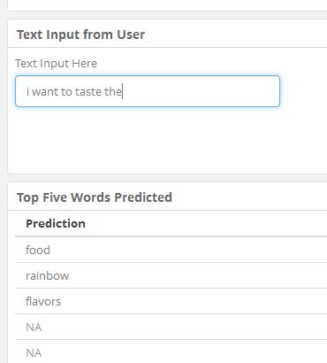